# Basic data handling and visualization

# 0. Before we begin

This course assumes some basic experience with R and R-studio. If you feel you are experiencing some hard time with these after this class please come talk to me.

There are plenty of R packages dedicated to network analysis in general and to ecological networks in particular (also for more general biological networks). In this course we will present several of them, but you can always choose those that are more convenient to you. We will especially work with `bipartite` and `igraph`. Let’s make sure you have them installed. Then load them. You can do that via the Packages tab in R-studio or by typing:

```r
# install.packages('igraph')
library('igraph')
# install.packages('bipartite')
library('bipartite')
```

Each of these packages contains many functions for analyzing and vizuliazing networks. A great resource for igraph is http://igraph.org/r/doc/. We will cover only a few of these but once you get the basics you can use any function you want. Remember to **always read the description of the function in the help file, and if this is a major part of your analysis, go to the original references**. Let’s try one example for getting help. Note the `igraph::` prefix. This tells R that the betweenness command is from the `igraph` package, since it also appears in the `sna` package, loaded by `bipartite`.

```r
?igraph::betweenness()
```

Note: It is of course impossible to know every command, function, argument and option. Therefore, many times we will rely on our best friend Google to search for solutions and help. Particularly we recommend Stack Exchange (or stack overflow). As an example try searching in google for: “creating binary matrix in r”!

# 1. Data structures

Networks can be represented using several data structures. Knowing these data structures and how to transform from one to another is a very handy skill as even within `R` different packages use different structures. The two main data structures are *matrices* and *edge lists* and we will focus on those. These are general and not specific to R. There are, however, some data structures which are specific to differnt R packages and we will deal with those as we go along.

Note: During this section we will meet some basics of `igraph`. While it is not the main goal of this section, it is a good intro.

## 1.1 Networks as matrices

The most obvious way to represent a network is by using a matrix $A$ in which rows (the $i$ index) and columns (the $j$ index) represent the nodes and a matrix entry $A_{ij}$ is an edge. In a *binary*, or *unweighted*, matrix cells can be either 0 (no edge) or 1 (an edge exists). In a *weighted*, or *quantitative* matrix cells can have a different value than 1. A matrix is *symmetric* if $A_{ij}=A_{ji}, \forall i,j$ and *asymmetric* otherwise. A symmetric matrix represents an *undirected* network, whereas an asymmetric matrix represents a *directed* network.

### Unweighted networks

Let’s see an example for an undirected graph:

```r
A_u <- matrix(c(0,1,1,0,0, # An example input matrix
              1,0,0,1,1,
              1,0,0,0,0,
              0,1,0,0,0,
              0,1,0,0,0),5,5, byrow=F)
isSymmetric(A_u)
```

```
## [1] TRUE
```

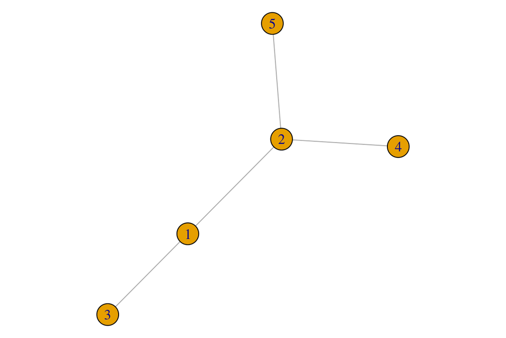

```r
g <- igraph::graph.adjacency(A_u, mode = 'undirected')
par(mar=c(0,0,0,0))
plot(g)
```

And for a directed graph:

```r
A_d <- matrix(c(0,1,1,0,1, # An example input matrix
              1,0,0,1,1,
              1,0,0,0,0,
              0,1,0,0,0,
              0,1,1,0,0),5,5, byrow=F)
isSymmetric(A_d)
```

```
## [1] FALSE
```

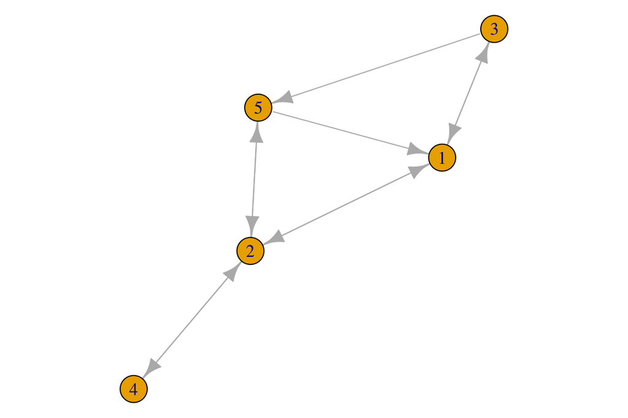

```r
g <- igraph::graph.adjacency(A_d, mode = 'directed')
par(mar=c(0,0,0,0))
plot(g)
```

> 1. Try to add a self-loop to one of the networks.
> 2. Try to create a directed graph in which there is a singleton (a node without any interactions).
> 3. What are the advantages of representing networks as matrices? What are the disadvantages?

### Weighted networks

For the sake of the example, we will create a network with some random edge weights. Again we will have 5 nodes with 4 edges in an undirected network.

```r
A_w <- matrix(c(0,1,1,0,0, # An example input matrix
              1,0,0,1,1,
              1,0,0,0,0,
              0,1,0,0,0,
              0,1,0,0,0),5,5, byrow=F)
random_weights <- round(rnorm(10, 10, 4),2) # take weights from a normal distribution.
A_w[lower.tri(A_w)] <- A_w[lower.tri(A_w)]*random_weights # Fill the lower traiangle
A_w <- A_w+t(A_w) # This makes the matrix symmetric
isSymmetric(A_w)
```

```
## [1] TRUE
```

```r
g <- igraph::graph.adjacency(A_w, mode = 'undirected', weighted = T)
E(g)$weight
```

```
## [1]  8.47 17.02 13.57 14.37
```

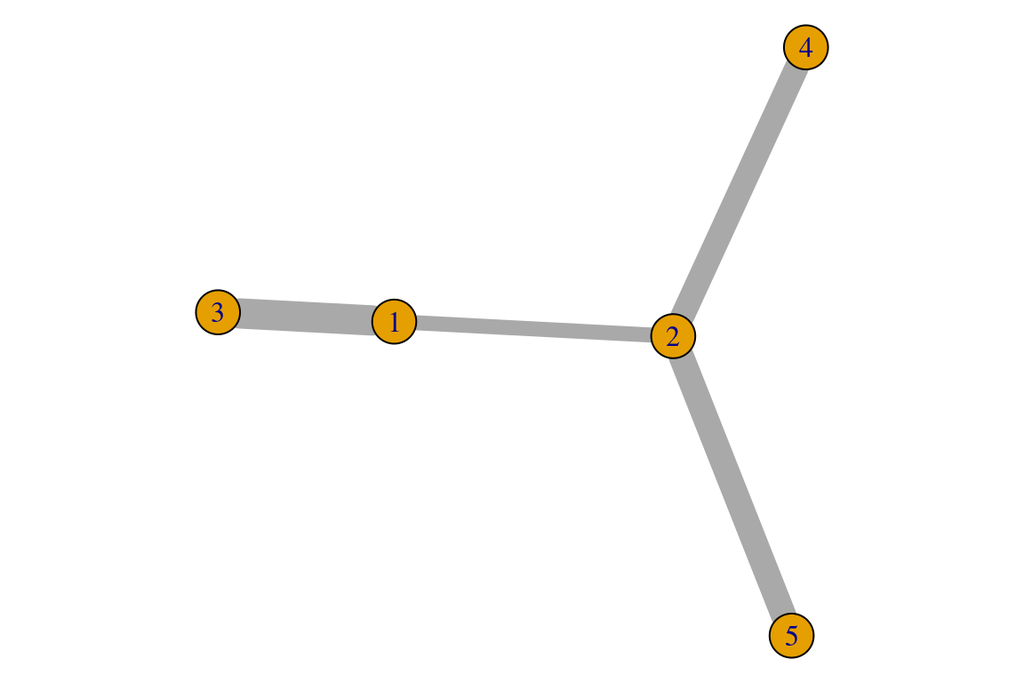

```r
par(mar=c(0,0,0,0))
plot(g, edge.width=E(g)$weight)
```

> 4. Try do follow the code above to create a directed weighted network.

Note that in this course we will refer to an *edge* as a component of the network and to an *interaction* as an ecological interaction. For example, predation is an ecological interaction represented as an edge in a food web. > What can edge weights be in ecological networks? Try to think of at least 3 diffeterent measures for an ecological interaction.

## 1.2 Networks as edge lists

### Unweighted

Edge lists for unweighted networks are basically a table with 2 columns and as many rows as there are interactions. A simple example would be the equivalent for the network we previously represented with a matrix:

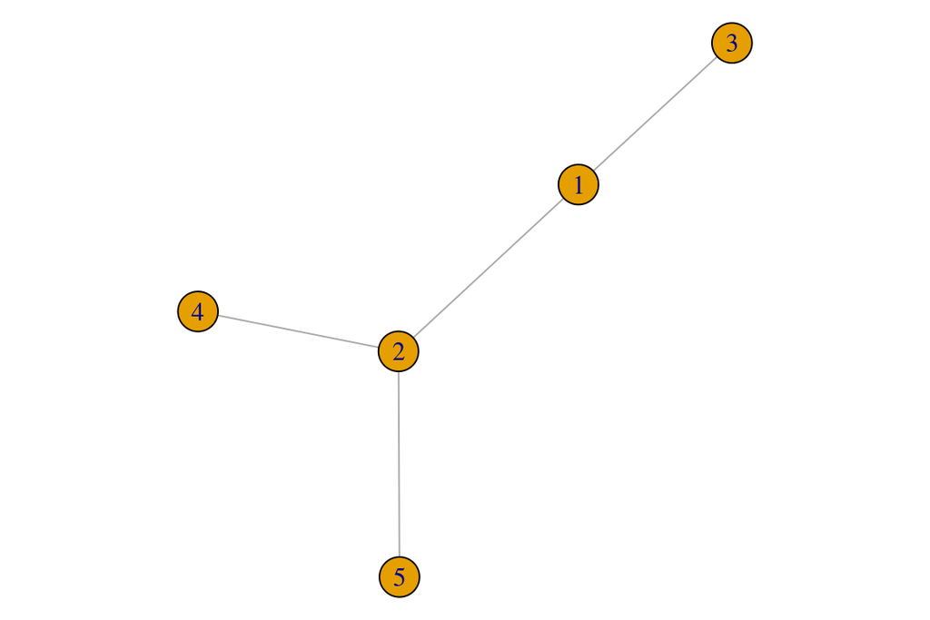

```r
L_u <- data.frame(i=c(1,1,2,2),
                j=c(2,3,4,5))
g <- igraph::graph.data.frame(L_u, directed = F)
par(mar=c(0,0,0,0))
plot(g)
```

For the directed network:

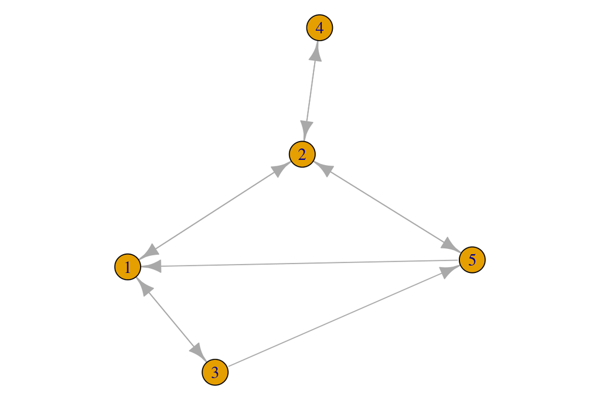

```r
L_u <- data.frame(i=c(1, 1, 2, 2, 2, 3, 3, 4, 5, 5),
                j=c(2, 3, 1, 4, 5, 1, 5, 2, 1, 2))
g <- igraph::graph.data.frame(L_u, directed = T)
par(mar=c(0,0,0,0))
plot(g)
```

Note that for directed networks it may be more convenient to label the columns using `from` and `to` than `i` and `j`.

> 5. Try to add a self-loop to the edge list, using from and to as column names.

### Weighted

An edge list for a weighted network requires an additional column for matrix weights. Following the previous examples for undirected networks:

```r
L_w <- data.frame(i=c(1,1,2,2),
                j=c(2,3,4,5),
                weight=round(rnorm(4, 10, 4),2) # take weights from a normal distribution.
                )
g <- igraph::graph.data.frame(L_w, directed = F)
E(g)$weight
```

```
## [1] 7.89 9.53 9.07 9.60
```

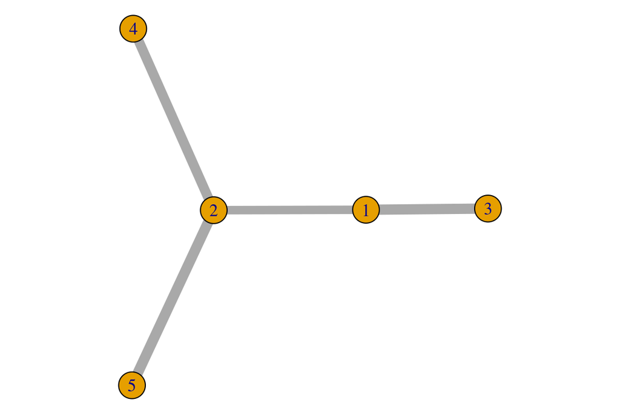

```r
par(mar=c(0,0,0,0))
plot(g, edge.width=E(g)$weight)
```

And for directed networks:

```r
L_wd <- data.frame(from=c(1, 1, 2, 2, 2, 3, 3, 4, 5, 5),
                to=c(2, 3, 1, 4, 5, 1, 5, 2, 1, 2),
                weight=round(rnorm(10, 1, 0.2),2))
g <- igraph::graph.data.frame(L_wd, directed = T)
g
```

```
## IGRAPH 6167370 DNW- 5 10 --
## + attr: name (v/c), weight (e/n)
## + edges from 6167370 (vertex names):
##  [1] 1->2 1->3 2->1 2->4 2->5 3->1 3->5 4->2 5->1 5->2
```

```r
E(g)$weight
```

```
##  [1] 1.02 0.84 1.18 1.25 0.94 1.20 0.39 0.91 0.98 1.11
```

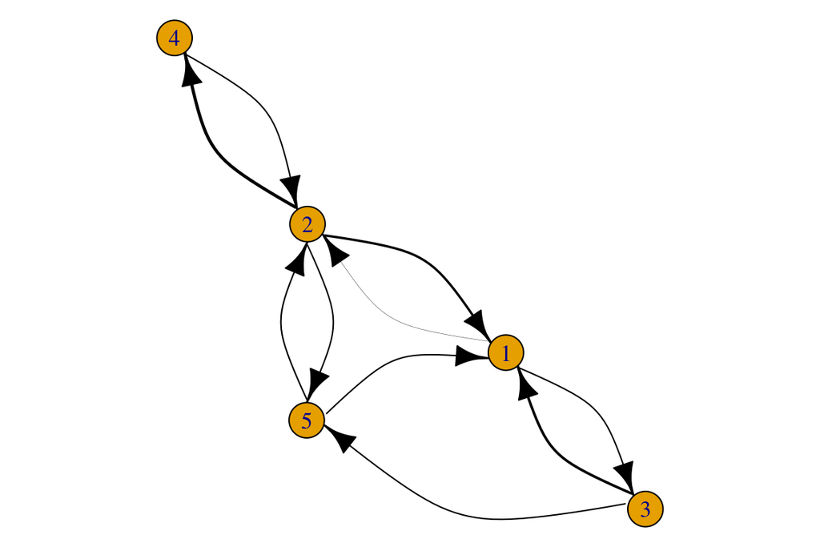

```r
par(mar=c(0,0,0,0))
plot(g, edge.width=log(E(g)$weight)*10, # possible to rescale edge weights when plotting
       edge.arrow.size=1.2,
       edge.curved=0.5,
     edge.color='black')
```

> 6. What are the advantages/disadvantages of edge lists compared to matrices?

## 1.3 Converting between matrices and edge lists

Because different implementations use different data structures, converting between these two is rather important. We will first do that in igraph. Working with igraph is fast (especially when working with large and/or dense networks), economic in code, flexible and in most cases delivers what we want. So it is highly recommended. But that is cheating!!! So we will also program this ourselves.

Matrix to edge list:

```r
A_w
```

```
##       [,1]  [,2]  [,3]  [,4]  [,5]
## [1,]  0.00  8.47 17.02  0.00  0.00
## [2,]  8.47  0.00  0.00 13.57 14.37
## [3,] 17.02  0.00  0.00  0.00  0.00
## [4,]  0.00 13.57  0.00  0.00  0.00
## [5,]  0.00 14.37  0.00  0.00  0.00
```

```r
g <- igraph::graph.adjacency(A_w, mode = 'directed', weighted = T)
L <- igraph::as_data_frame(g, what = 'edges')
L
```

```
##   from to weight
## 1    1  2   8.47
## 2    1  3  17.02
## 3    2  1   8.47
## 4    2  4  13.57
## 5    2  5  14.37
## 6    3  1  17.02
## 7    4  2  13.57
## 8    5  2  14.37
```

Edge list to matrix:

```r
L_wd
```

```
##    from to weight
## 1     1  2   1.02
## 2     1  3   0.84
## 3     2  1   1.18
## 4     2  4   1.25
## 5     2  5   0.94
## 6     3  1   1.20
## 7     3  5   0.39
## 8     4  2   0.91
## 9     5  1   0.98
## 10    5  2   1.11
```

```r
g <- igraph::graph.data.frame(L_wd, directed = T)
A <- igraph::as_adjacency_matrix(g, attr = 'weight', sparse=F)
A
```

```
##      1    2    3    4    5
## 1 0.00 1.02 0.84 0.00 0.00
## 2 1.18 0.00 0.00 1.25 0.94
## 3 1.20 0.00 0.00 0.00 0.39
## 4 0.00 0.91 0.00 0.00 0.00
## 5 0.98 1.11 0.00 0.00 0.00
```

> 7. Try programming a function that takes a matrix and returns an edge list. Note that it may be important if the matrix is directed or weighted.
> 8. Try programming a function that takes an edge list and returns a matrix. Note that it may be important if the matrix is directed or weighted.

# 2. Bipartite networks

## 2.1 Loading data

We start with bipartite networks because the `R` methodology to handle them is simpler. First, we need to import data. `bipartite` has several data sets implemented. Let’s try one:

```r
data("memmott1999") # load
class(memmott1999)
```

```
## [1] "matrix"
```

```r
memmott1999[1:4,1:4] # view first lines
```

```
##                       Coleoptera.spec1 Coleoptera.spec2 Coleoptera.spec3
## Agrimonium.eupatorium                0                0                0
## Leontodon.autumnalis                 0                0                0
## Lotus.corniculatus                   0                0                0
## Medicago.lupulina                    0                0                0
##                       Coleoptera.spec4
## Agrimonium.eupatorium                0
## Leontodon.autumnalis                 0
## Lotus.corniculatus                   0
## Medicago.lupulina                    0
```

> 9. Now try to load a different data set. Where can you find available ones?

## 2.2 Visualizaing data

Usually, the first thing we would like to do is take a look at the network. As you remember, a network is a matrix. We can visualize the matrix using:

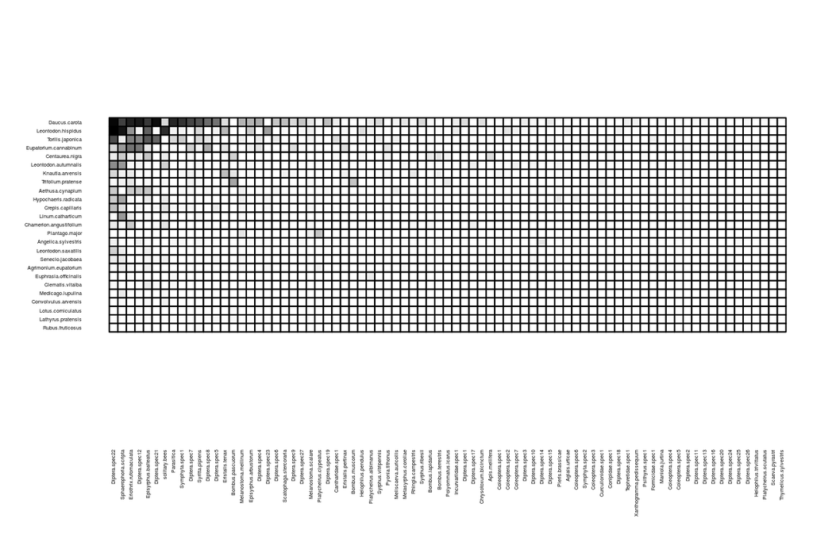

```r
visweb(memmott1999)
```

Can you see the different hues? This is a *quantitative network*, where matrix cell values indicate the strength of an ecological interaction. Sometimes it is useful to look only at the edges (regardless of values), in a binary network. So we only want to see those entries larger than 0.

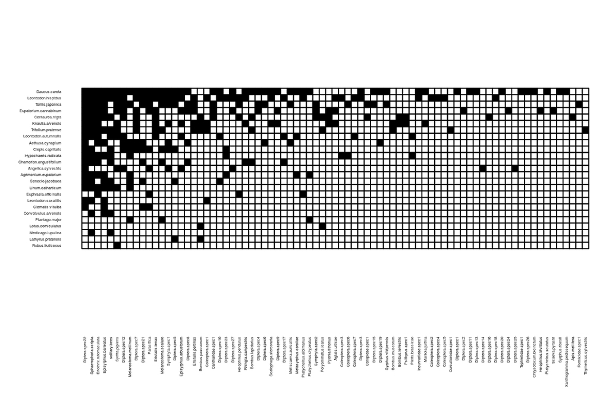

```r
memmott1999_binary <- 1*(memmott1999>0)
visweb(memmott1999_binary)
```

visweb works OK for small networks, although as you can see, it may need some tweaking to improve the plotting… We can do that by using the function’s options, just like with any other function in `R`. An examplpe:

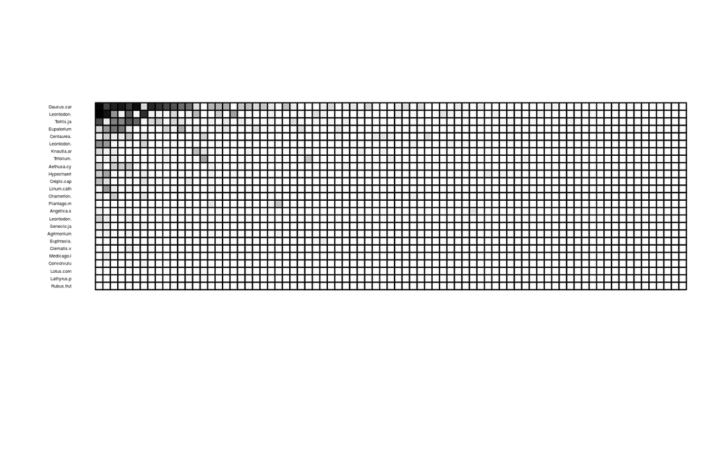

```r
visweb(memmott1999,prednames = F, prey.lablength = 10)
```

Another way to plot a bipartite network is by connecting nodes with lines:

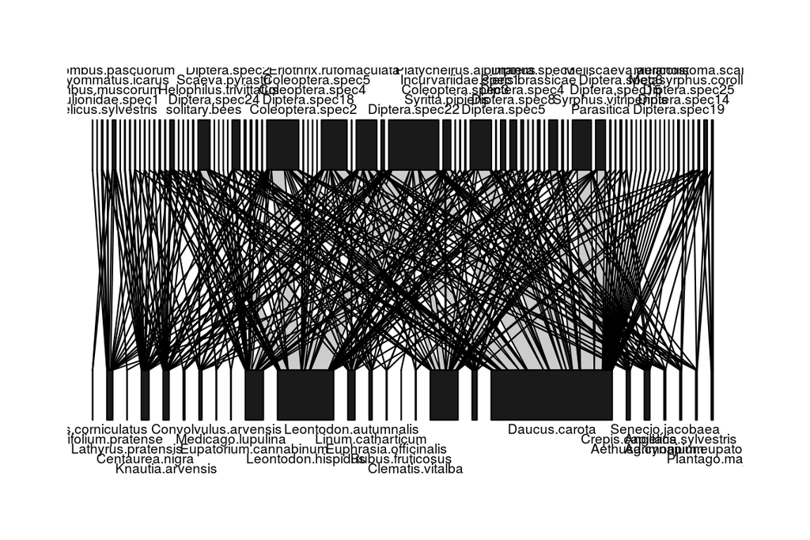

```r
plotweb(memmott1999)
```

> 10. Can you say something about the network using this representation? What does it reveal just by looking?
> 11. Try to browse through the options in plotweb and tweak the plot.

## 2.3 Importing data

Built-in data sets are great for practicing but usually we study external data sets. In this course we will import data sets from standard text files like csv and txt. It is not trivial to work with external data, especially when the metadata is spread across several files. Usually you will need an ad-hoc way to deal with your data, so as you go you will definetly master your data management skills in `R`!

Let’s start with a simple example. This is a host-parasite network.

```r
ural_data <- read.csv('https://raw.githubusercontent.com/pascualgroup/Networks_course/master/Network_data/Ural_valley_A_HP_048.csv?token=ADd8OH8_dgTW2e0V71XhqCX5EXsT0i2mks5awrkRwA%3D%3D')
```

This file is not as clean. Let’s take a look and prepare it.

```r
ural_data[1:4,1:4]
```

```
##                         X Num..of.hosts.sampled Ctenophthalmus.wagneri
## 1 Clethrionomys glareolus                  5209                   1748
## 2      Apodemus uralensis                 15198                   1408
## 3        Microtus arvalis                  1920                    494
## 4           Sorex araneus                   856                    237
##   Nosopsyllus.consimilis
## 1                    337
## 2                    893
## 3                    193
## 4                      6
```

The first column is species names and the second is the number of hosts sampled, and the rest of the columns are the parasites. Columns 1 and 2 are not part of the network itself. So we will put the hosts as the row names and remove the number of hosts sampled. We also want the data as a matrix, rather than a data frame.

```r
rownames(ural_data) <- ural_data[,1] # Set row names
num_hosts_sampled <- ural_data[,2] # save in a variable
ural_data <- ural_data[,-2] # remove column
ural_data <- ural_data[,-1] # remove column
class(ural_data) # This is a data frame!
```

```
## [1] "data.frame"
```

```r
ural_data <- data.matrix(ural_data) # Transform to a matrix format
ural_data[1:4,1:4]
```

```
##                         Ctenophthalmus.wagneri Nosopsyllus.consimilis
## Clethrionomys glareolus                   1748                    337
## Apodemus uralensis                        1408                    893
## Microtus arvalis                           494                    193
## Sorex araneus                              237                      6
##                         Megabothris.turbidus Amphipsylla.rossica
## Clethrionomys glareolus                  811                 144
## Apodemus uralensis                       414                  41
## Microtus arvalis                          97                 177
## Sorex araneus                             20                   4
```

> 12. Try to plot the Ural Valley data!

## 2.4 Metadata

Obviously, it is extremely important we understand the data we are looking at and working with. What are the species? what are the edges? Where were the data collected? How? For the built-in data sets we can just use the help (e.g., `?memmott1999`. For other data sets it is necessary to go to the original publication. For the Ural Valley data the description is [here](http://datadryad.org/resource/doi:10.5061/dryad.jf3tj/4).

A bipartite network has two guilds. As a convention, the rows are the “lower” trophic level (e.g., plants, hosts) and the columns are the “higher” trophic level (e.g., pollinators, parasites).

```r
plant_species <- rownames(memmott1999)
flower_visitor_species <- colnames(memmott1999)
head(plant_species, 3)
```

```
## [1] "Agrimonium.eupatorium" "Leontodon.autumnalis"  "Lotus.corniculatus"
```

```r
head(flower_visitor_species, 3)
```

```
## [1] "Coleoptera.spec1" "Coleoptera.spec2" "Coleoptera.spec3"
```

These data sets were a simple example. In our next section about food webs, you will see that metadata usually is much richer.

# 3. Unipartite networks

Food webs are a classic example of a unipartite network and are by far the most studied kind of netwok in ecology. Typically, the structure of the data of food webs is more complex than that of bipartite networks. As an example, let’s explore the Otago Lake (NZ) food web. The description of the data is a data paper in [Ecological Archives E092-173-D1](http://www.esapubs.org/Archive/ecol/E092/173/default.htm).

> 13. Browse through the metadata and particularly the “Data Set Structural Descriptors”.

We have already downloaded the nodes and links for this class. Let’s load the network:

```r
otago_nodes <- read.csv('https://raw.githubusercontent.com/pascualgroup/Networks_course/master/Network_data/Otago_Data_Nodes.csv?token=ADd8OGnaV0qMolv_YslyRlkYegPJVjLxks5awrkjwA%3D%3D')
otago_links <- read.csv('https://raw.githubusercontent.com/pascualgroup/Networks_course/master/Network_data/Otago_Data_Links.csv?token=ADd8OH_GXVK3HoD_9YVCFGkAXp0PrUAEks5awrk0wA%3D%3D')
otago_nodes[1:4,1:6]
```

```
##   NodeID SpeciesID StageID Stage Species.StageID         WorkingName
## 1      1         1       1 Adult             1.1       Phytoplankton
## 2      2         2       1 Adult             2.1     Epipellic Flora
## 3      3         3       1 Adult             3.1 Macroalgae/Seagrass
## 4      4         4       1 Adult             4.1         Zooplankton
```

```r
otago_links[1:4,1:8]
```

```
##   ConsumerNodeID ResourceNodeID ConsumerSpeciesID ResourceSpeciesID
## 1              4              1                 4                 1
## 2              4              4                 4                 4
## 3              4              6                 4                 6
## 4              5              1                 5                 1
##   ConsumerSpecies.StageID ResourceSpecies.StageID LinkTypeID  LinkType
## 1                       1                       1          1 Predation
## 2                       1                       1          1 Predation
## 3                       1                       1          1 Predation
## 4                       1                       1          1 Predation
```

As you can see these are data frames, which contain a lot of information besides a simple network. `igraph` can handle many ways to import data to generate igraph network objects. Let’s import that data frame (we have seen that previously in the lab):

```r
otago_web <- graph.data.frame(otago_links, vertices = otago_nodes, directed = T)
```

The `graph.` commands import different kinds of data structures. The advantage of importing a data frame is that igraph also imports the *attributes* of the edges. The edge attributes are imported from the edge data frame (`otago_links`) and the node attributes are imported using the `vertices=` argument pointing to a data frame with node attributes. We can access edge and vertex attributes with `E` and `V`, respectively.

```r
names(edge.attributes(otago_web))
```

```
##  [1] "ConsumerSpeciesID"       "ResourceSpeciesID"
##  [3] "ConsumerSpecies.StageID" "ResourceSpecies.StageID"
##  [5] "LinkTypeID"              "LinkType"
##  [7] "LinkEvidence"            "LinkEvidenceNotes"
##  [9] "LinkFrequency"           "LinkN"
## [11] "DietFraction"            "ConsumptionRate"
## [13] "VectorFrom"              "PreyFrom"
```

```r
unique(E(otago_web)$LinkType)
```

```
##  [1] "Predation"
##  [2] "Parasitic Castration"
##  [3] "Macroparasitism"
##  [4] "Commensalism"
##  [5] "Trophically Transmitted Parasitism"
##  [6] "Concomitant Predation on Symbionts"
##  [7] "Trophic Transmission"
##  [8] "Predation on free-living non-feeding stages"
##  [9] "Predation on commensal non-feeding stages"
## [10] "Parasite intraguild trophic interaction"
```

```r
names(vertex.attributes(otago_web))
```

```
##  [1] "name"                    "SpeciesID"
##  [3] "StageID"                 "Stage"
##  [5] "Species.StageID"         "WorkingName"
##  [7] "OrganismalGroup"         "NodeType"
##  [9] "Resolution"              "ResolutionNotes"
## [11] "Feeding"                 "Lifestyle.stage."
## [13] "Lifestyle.species."      "ConsumerStrategy.stage."
## [15] "System"                  "HabitatAffiliation"
## [17] "Mobility"                "Residency"
## [19] "NativeStatus"            "BodySize.g."
## [21] "BodySizeEstimation"      "BodySizeNotes"
## [23] "BodySizeN"               "Biomass.kg.ha."
## [25] "BiomassEstimation"       "BiomassNotes"
## [27] "Kingdom"                 "Phylum"
## [29] "Subphylum"               "Superclass"
## [31] "Class"                   "Subclass"
## [33] "Order"                   "Suborder"
## [35] "Infraorder"              "Superfamily"
## [37] "Family"                  "Genus"
## [39] "SpecificEpithet"         "Subspecies"
## [41] "NodeNotes"
```

```r
head(unique(V(otago_web)$name))
```

```
## [1] "1" "2" "3" "4" "5" "6"
```

The values of `name` are those from the `ConsumerNodeID` and `ResourceNodeID` columns in `otago_links`.

> 14. Try to load a new food web, the Bahia Falsa. The Bahia Falsa data set is described [here](http://datadryad.org/resource/doi:10.5061/dryad.b8r5c). An edge list can be found [here](https://raw.githubusercontent.com/pascualgroup/Networks_course/master/Network_data/Bahia_falsa_Hechinger2011.csv?token=ADd8OBIQkNtPbAQ3lNPaM0buoor2Wee5ks5awrlowA%3D%3D). And species names are [here](https://raw.githubusercontent.com/pascualgroup/Networks_course/master/Network_data/Bahia_falsa_Hechinger2011_species_list.csv?token=ADd8OAzXejCLAO_oGUtFQCsMFagpckhNks5awrl-wA%3D%3D).

# 4. Plotting with igraph

Finally, let’s try to plot. We have already seen how to call a basic plot:

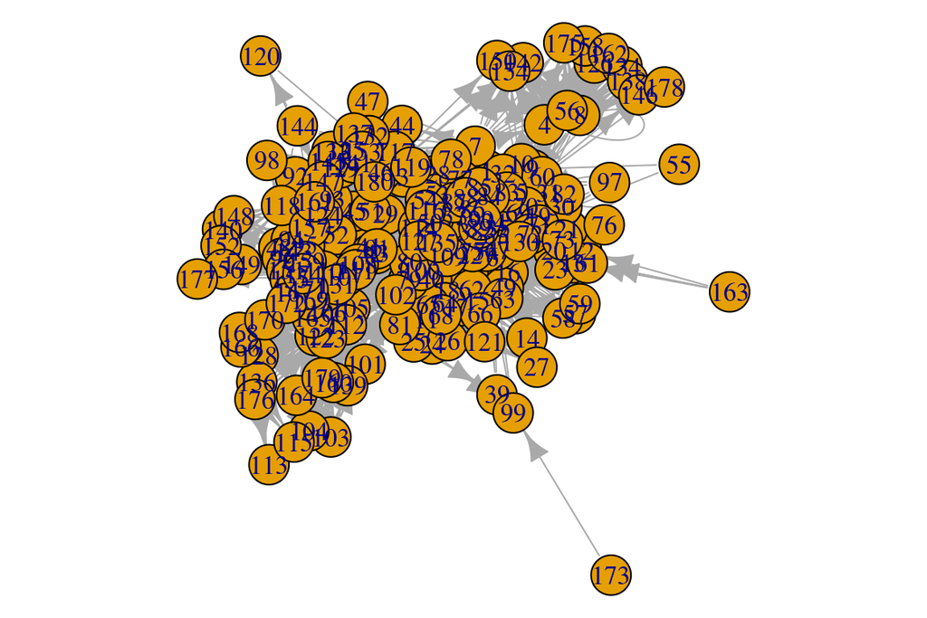

```r
par(mar=c(0,0,0,0)) #Reduce margin size
plot(otago_web)
```

What a mess… We can definitely make this nicer!!! There are many many ways to tweak igraph plots. Check out that resource: http://igraph.org/r/doc/plot.common.html. And of course our best friend StackOverflow will have many answers for specific questions.

Here is a nicer plot with some tweaks:

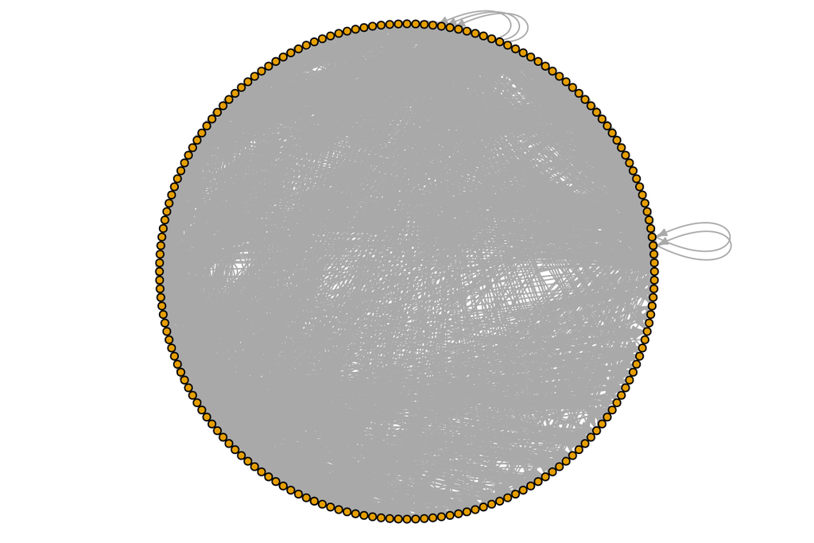

```r
par(mar=c(0,0,0,0))
plot(otago_web, vertex.size=3, edge.arrow.size=0.4, vertex.label=NA, layout=layout.circle)
```

Now, let’s try to both set link attributes and use them for plotting. We will color edges by the type of interactin they represent:

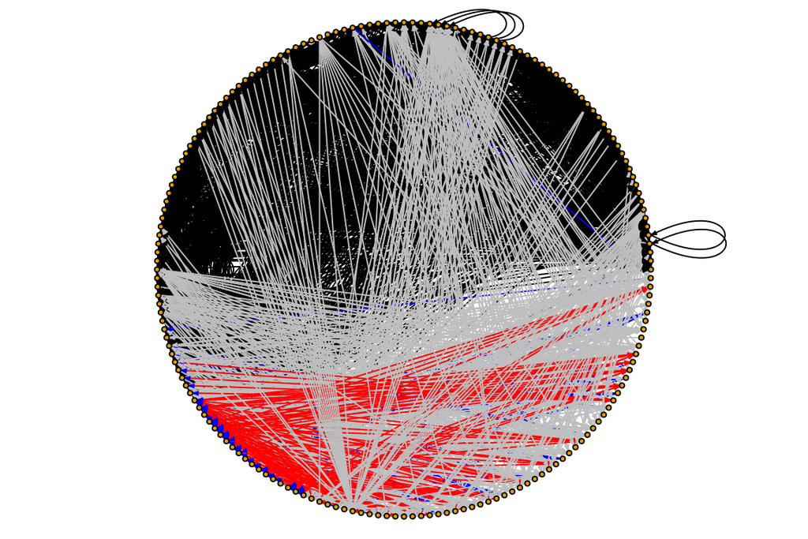

```r
E(otago_web)$color <- "grey" # First, we set a default color
E(otago_web)[otago_links$LinkType == 'Predation']$color <- "black"
E(otago_web)[otago_links$LinkType == 'Macroparasitism']$color <- "blue"
E(otago_web)[otago_links$LinkType == 'Trophic Transmission']$color <- "red"
# Now plot
par(mar=c(0,0,0,0))
plot(otago_web, vertex.size=2, edge.arrow.size=0.2, vertex.label=NA, layout=layout.circle)
```

In food webs, species can be divided into three main trophic groups: basal, intermediate and top predators. Let’s try to clasify the species on the Otago food web.

```r
# Basal species (those that do not consume) -- do not have incoming links
basal <- which(igraph::degree(otago_web, mode = 'in') == 0)
# Top species do not have outgoing links
top <- which(igraph::degree(otago_web, mode = 'out') == 0)
# Intermediate are all the rest
interm <- V(otago_web)[which(!V(otago_web) %in% c(basal,top))]
# Are all the nodes included?
all(c(basal,top,interm) %in% V(otago_web))
```

```
## [1] TRUE
```

```r
all(V(otago_web) %in% c(basal,top,interm))
```

```
## [1] TRUE
```

Now let’s try to re-plot the food web using these classifications. We will use our own layout, which is a matrix with coordinates.

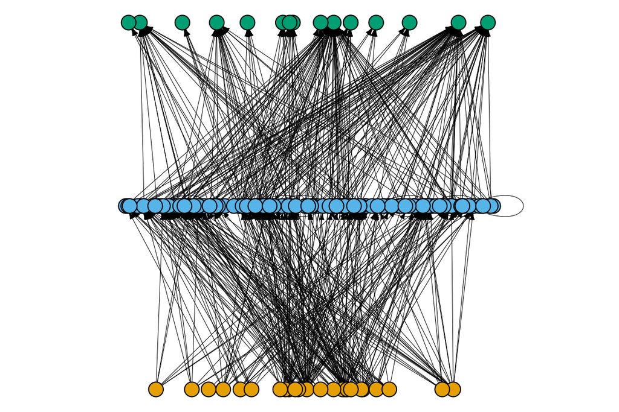

```r
V(otago_web)$troph_pos <- rep(0,length(V(otago_web)))
V(otago_web)$troph_pos[which(V(otago_web)$name %in% basal)] <- 1
V(otago_web)$troph_pos[which(V(otago_web)$name %in% top)] <- 3
V(otago_web)$troph_pos[which(V(otago_web)$name %in% interm)] <- 2
# create a matrix forthe layout coordinates.
coords <- matrix(nrow=length(V(otago_web)), ncol=2) #
# The x positions are randomly selected
coords[,1] <- runif(length(V(otago_web)))
# The y positions are the trophoc positions
coords[,2] <- V(otago_web)$troph_pos
par(mar=c(0,0,0,0))
plot(otago_web,layout=coords,
            vertex.color=V(otago_web)$troph_pos,
            vertex.label=NA,
            vertex.size=8,
            edge.color='black',
            edge.arrow.size=.3,
            edge.width=.5)
```

> 15. Try to set other node and edge attributes based on `otago_nodes` and `otago_links`. For example, try to color nodes by `OrganismalGroup` and plot. Does the organismal group correspond to the trophic position?

# 5. External resources for data

There is a lot of network data out there, in all kinds and flavors: food webs, host-parasite, plant-pollinator networks, and much more. Where do you think we can get data? What repositories or resources are available?

> 16. Find 5 different repositories or data sources for ecological networks.
> 17. Try to obtain 2 data sets from 2 different repositories, load them and plot them.

# 6. Suggested reading

1. Pocock MJO, Evans DM, Fontaine C, Harvey M, Julliard R, McLaughlin Ó, et al. Chapter Two - The Visualisation of Ecological Networks, and Their Use as a Tool for Engagement, Advocacy and Management. In: Woodward G, Bohan DA, editors. Advances in Ecological Research. Academic Press; 2016. pp. 41–85.
2. Poisot T, Baiser B, Dunne JA, Kéfi S, Massol F, Mouquet N, et al. mangal – making ecological network analysis simple. Ecography. Blackwell Publishing Ltd; 2015; doi:10.1111/ecog.00976